# Conception d'une voiture autonome

[figure not shown]

La mission qui m'a été confié au sein de Future Vision Transport est de segmenter les images traitées par Franck au préalable. Nous allons entrainer différents modèles et selectionner le plus performant, puis deployer le modèle sur Azure qui sera accessible via API afin de faire de nouvelle prédiction facilement.

```python
import os
import random
from time import time
from pathlib import Path
from helpers.labels import labels, assureSingleInstanceName

import albumentations as A
import numpy as np
import pandas as pd
import cv2
import matplotlib.pyplot as plt

import tensorflow as tf
from tensorflow.keras.metrics import MeanIoU
from tensorflow.keras import backend as K
from tensorflow.keras.losses import binary_crossentropy
from tensorflow.keras.utils import Sequence
from tensorflow.keras.callbacks import EarlyStopping, ModelCheckpoint, Callback
from tensorflow.keras.preprocessing import image

SM_FRAMEWORK=tf.keras
import segmentation_models as sm
sm.set_framework('tf.keras')
from segmentation_models.losses import dice_loss, jaccard_loss
from segmentation_models.metrics import iou_score, f1_score
```

```python
import tensorflow as tf
print(tf.__version__)
print(len(tf.config.list_physical_devices('GPU'))>0)
```

```
2.8.0
True
```

```python
path_original_image = 'data/leftImg8bit/'

def lenght_dataset(path):
    count_train = 0
    count_val = 0
    count_test = 0

    for directory in os.listdir(path):
        if directory == "train":
            path_train = path + 'train/'
            for subdir in os.listdir(path_train):
                count_train += len(os.listdir(path_train + subdir))

        if directory == "val":
            path_val = path + 'val/'
            for subdir in os.listdir(path_val):
                count_val += len(os.listdir(path_val + subdir))

        if directory == "test":
            path_test = path + 'test/'
            for subdir in os.listdir(path_test):
                count_test += len(os.listdir(path_test + subdir))


    print('Train dataset:', count_train, 'images.')
    print('Val dataset:', count_val, 'images.')
    print('Test dataset:', count_test, 'images.')
```

```python
lenght_dataset(path_original_image)
```

```
Train dataset: 2975 images.
Val dataset: 500 images.
Test dataset: 1525 images.
```

## I) Mise en place des données

### 1.1) Creation des fonctions pour la mise en place des données

Nous allons ici mettre en place nos données afin de pouvoir entrainer nos différents modèles. Nous allons aussi mettre en place un moyen de passer des 34 classes aux 8 principales classes.

Differents dictionnaires qui nous serons utiles pour faire la correspondance entre les 34 classes de base et les 8 classes au final :

```python
# name to label object
name2label = {label.name: label for label in labels}

# id to label object
id2label = {label.id: label for label in labels}

# id to label object
labelid2catid = {label.id: label[4] for label in labels}

# trainId to label object
trainId2label = {label.trainId: label for label in reversed(labels)}

# category to list of label objects
category2labels = {}
for label in labels:
    category = label.category
    if category in category2labels:
        category2labels[category].append(label)
    else:
        category2labels[category] = [label]

# id to label object
catid2color = {label[0].categoryId: list(label[0].color) for label in category2labels.values()}
category2catid = {cat: label[0].categoryId for cat, label in category2labels.items()}
```

Creation de notre générateur qui va permettre de faire du multiprocessing :

```python
class Generator(Sequence):

    def __init__(self, images_dir_list, masks_dir_list,cat2id,
                 labelid2catid,dim=(256,128), apply_augmentation=False,
                 batch_size=1, shuffle=False):
        self.batch_size = batch_size
        self.shuffle = shuffle
        self.indexes = np.arange(len(images_dir_list))
        self.apply_augmentation = apply_augmentation
        self.images_fps = images_dir_list
        self.masks_fps = masks_dir_list
        self.dim = dim
        self.class_values = [idx for idx in cat2id.values()] # class values on masks
        self.labelid2catid = labelid2catid

        self.on_epoch_end()

    def __getitem__(self, i):

        # Our final batches of images and masks
        images = []
        masks = []

        # Get in the list of images by 16 images for each batch
        for n, (image_path, mask_path) in enumerate(zip(self.images_fps[i*self.batch_size:(i+1)*self.batch_size],
                                                        self.masks_fps[i*self.batch_size:(i+1)*self.batch_size])):

            # read image and resize
            image = cv2.imread(str(image_path))
            image = cv2.cvtColor(image, cv2.COLOR_BGR2RGB)
            image = cv2.resize(image, self.dim)

            # read mask and resize
            mask = cv2.imread(str(mask_path), 0)
            mask = cv2.resize(mask, self.dim)

            # Transform 34 classes to 8 classes
            for label_id, cat_id in self.labelid2catid.items():
                    mask[mask==label_id] = cat_id

            # extract 8 classes as depth/channels
            masks_channels = [(mask == v) for v in self.class_values]
            mask = np.stack(masks_channels, axis=-1).astype('float')

            # apply data augmentation
            if self.apply_augmentation:
                transform = get_training_augmentation()
                if transform is not None:
                    sample = transform(image=image, mask=mask)
                    image_aug, mask_aug = sample['image'], sample['mask']

                    # append image and mask augmented
                    images.append(image_aug)
                    masks.append(mask_aug)

                # append image and mask not augmented
                images.append(image)
                masks.append(mask)
            else:
                # append image and mask not augmented
                images.append(image)
                masks.append(mask)

        # return batches of images and masks
        return np.array(images), np.array(masks)


    def __len__(self):
        """Denotes the number of batches per epoch"""
        return int(np.ceil(len(self.images_fps) / float(self.batch_size)))
```

Definissons une fonction pour appliquer de la data augmentation à nos images :

```python
def get_training_augmentation():

    # Our 4 functions of augmentation
    train_transform = [
        A.HorizontalFlip(p=1),
        A.RandomBrightnessContrast(p=1),
        A.GaussianBlur(p=1),
        A.Affine(rotate=(-30,30),p=1),
    ]

    # get an integer randomly between 0 and 4 (included)
    k = random.randint(0,4)

    if k == 0:
        return None # No data augmentation will be apply
    else:
        return A.SomeOf(train_transform, n=k) # Apply k function of augmentation randomly
```

Voici un exemple de ce que produit notre fonction de data augmentation :

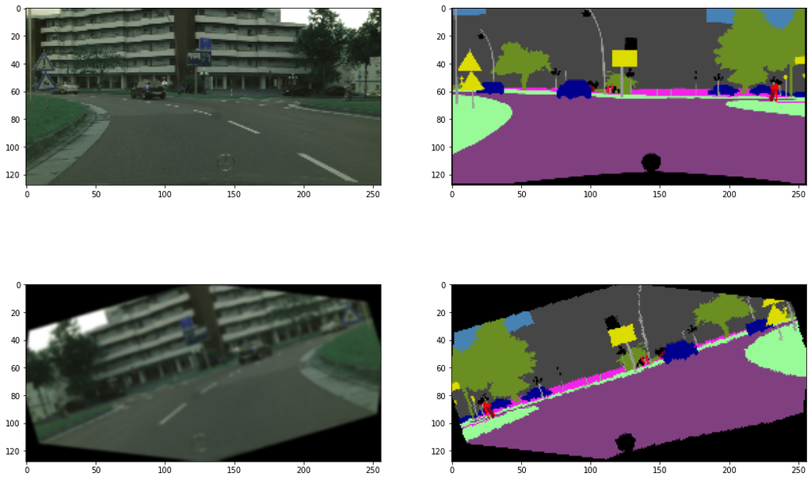

```python
# plot images
plt.figure(figsize=(18,12))

plt.subplot(2, 2, 1)
img = cv2.imread('data/leftImg8bit/train/aachen/aachen_000000_000019_leftImg8bit.png')
img = cv2.resize(img, (256,128))
plt.imshow(img)

plt.subplot(2, 2, 2)
img2 = cv2.imread('data/gtFine/train/aachen/aachen_000000_000019_gtFine_color.png')
img2 = cv2.cvtColor(img2.astype(np.uint8), cv2.COLOR_BGRA2RGB)
img2 = cv2.resize(img2, (256,128))
plt.imshow(img2)

transform = get_training_augmentation()
transformed = transform(image=img, mask=img2)

plt.subplot(2, 2, 3)
plt.imshow(transformed['image'])

plt.subplot(2, 2, 4)
plt.imshow(transformed['mask'])

plt.show()
```

Voici les 8 categories sur lesquells vont être entrainer nos modèles :

```python
# helper function for data visualization
def visualize(**images):
    """PLot images in one row."""
    n = len(images)
    plt.figure(figsize=(16, 28))
    for i, (name, image) in enumerate(images.items()):
        plt.subplot(6, 3, i + 1)
        plt.xticks([])
        plt.yticks([])
        plt.title(' '.join(name.split('_')).title())
        plt.imshow(image)
    plt.show()

# helper function for data visualization
def denormalize(x):
    """Scale image to range 0..1 for correct plot"""
    x_max = np.percentile(x, 98)
    x_min = np.percentile(x, 2)
    x = (x - x_min) / (x_max - x_min)
    x = x.clip(0, 1)
    return x
```

```python
leftImg8bit_path = Path('data', "leftImg8bit")
gtFine_path = Path('data', "gtFine")

X_train_path = list(Path(leftImg8bit_path, "train").glob("**/*_leftImg8bit.png"))
y_train_path = list(Path(gtFine_path, "train").glob("**/*_labelIds.png"))

gen = Generator(X_train_path, y_train_path, cat2id=category2catid,
                  labelid2catid=labelid2catid, apply_augmentation=get_training_augmentation())
```

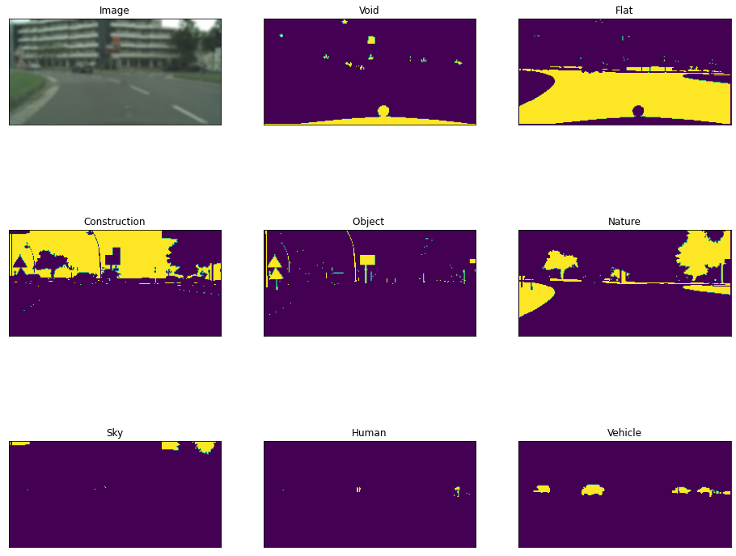

```python
image, mask = gen.__getitem__(0)[0][0], gen.__getitem__(0)[1][0]
visualize(
    image=image,
    void=mask[..., 0].squeeze(),
    flat=mask[..., 1].squeeze(),
    construction=mask[..., 2].squeeze(),
    object_=mask[..., 3].squeeze(),
    nature=mask[..., 4].squeeze(),
    sky=mask[..., 5].squeeze(),
    human=mask[..., 6].squeeze(),
    vehicle=mask[...,7].squeeze(),
)
```

### 1.2) Mise en place des données

Listons les chemins vers nos données train et val :

```python
leftImg8bit_path = Path('data', "leftImg8bit")
gtFine_path = Path('data', "gtFine")

X_train_path = list(Path(leftImg8bit_path, "train").glob("**/*_leftImg8bit.png"))
y_train_path = list(Path(gtFine_path, "train").glob("**/*_labelIds.png"))

X_val_path = list(Path(leftImg8bit_path, "val").glob("**/*_leftImg8bit.png"))
y_val_path = list(Path(gtFine_path, "val").glob("**/*_labelIds.png"))
c_val_path = list(Path(gtFine_path, "val").glob("**/*_color.png"))
```

```python
BATCH_SIZE = 16
EPOCHS = 25
```

## II) Modélisations

Nous allons essayer différentes simulations:

1. Modèles: Unet et LinkNet
2. Backbones: VGG19, ResNet18, MobileNet
3. Loss: Jaccard Loss
   - Cette fonction loss est l'inverse de la métrique IoU et permet d'optimiser son score.
4. Metriques: IoU (Jaccard)
   - Cette metrique qui est définie comme étant l'intersection de deux ensembles divisés par l'union de ces deux ensembles, permet dans notre cas de comparer le masque d'origine de l'image avec le masque prédit par le modèle. Donc si nos deux ensembles (ici notre masque d'origine et notre masque prédit) peuvent se superposer parfaitement (en termes de pixels) alors l'intersection des deux ensembles est égale à l'union, ayant ainsi un score de 1 de IoU. Dans le cas contraire où les ensembles ne se superpose pas parfaitement alors l'union des deux ensembles sera plus grand et le score IoU diminuera.

### 2.1) Mise en place des modèles

Mise en place de la fonction d'entrainement :

```python
df_results = pd.DataFrame(columns=['model', 'augmentation','image_size','train_time_epoch','loss_score','iou_score'])#'dice_coeff'])

# Function to make a DataFrame of results
def update_results(df_results, dict_results):
    df_results = df_results.append({
        'model': dict_results['name_model'],
        'augmentation': dict_results['augmentation'],
        'image_size': dict_results['image_size'],
        'train_time_epoch': dict_results['train_time_epoch'],
        'loss_score': dict_results['loss_score'],
        'iou_score': dict_results['iou_score'],
    }, ignore_index=True)

    df_results.to_csv(f"output/{dict_results['name_model']}_{dict_results['image_size']}_{dict_results['augmentation']}/results.csv",
                     index=False)

    return df_results

# Function to train models
def compute(name_model, model, size, train_gen, val_gen, augmentation=False):

    model.compile(loss=sm.losses.JaccardLoss(), optimizer='adam', metrics=[sm.metrics.IOUScore(threshold=0.5)])
    start_time = time()
    hist = model.fit(train_gen, validation_data=val_gen, epochs=EPOCHS,
                     callbacks=[EarlyStopping(monitor='val_loss', mode='min', verbose=1, patience=5),
                                ModelCheckpoint(f"output/{name_model}_{size[0]}_{size[1]}_{augmentation}/model.h5",
                                                monitor='val_loss', save_best_only=True),])
                                #Visualize(X_val_path, c_val_path, (size,size))])
    train_time = time() - start_time

    # eval model
    results_eval = model.evaluate(val_gen)


    return {
        'name_model': name_model,
        'model': model,
        'history': hist,
        'augmentation': augmentation,
        'image_size': size,
        'train_time_epoch': train_time/EPOCHS,
        'loss_score': results_eval[0],
        'iou_score': results_eval[1],
    }

# Function to plot history of training
def plot_history(history):
    # Plot training & validation iou_score values
    plt.figure(figsize=(30, 12))
    plt.subplot(121)
    plt.plot(history.history['iou_score'])
    plt.plot(history.history['val_iou_score'])
    plt.title('Model iou_score')
    plt.ylabel('iou_score')
    plt.xlabel('Epoch')
    plt.legend(['Train', 'Test'], loc='upper left')

    # Plot training & validation loss values
    plt.subplot(122)
    plt.plot(history.history['loss'])
    plt.plot(history.history['val_loss'])
    plt.title('Model loss')
    plt.ylabel('Loss')
    plt.xlabel('Epoch')
    plt.legend(['Train', 'Test'], loc='upper left')
    plt.show()
```

### 2.2) Entrainement

Entrainons tous nos modèles automatiquement :

```python
def compute_all_models(df_results):

    models = ['unet', 'linknet']
    backbones = ['vgg19','resnet18','mobilenet']
    aug_bools = [True, False]

    for model in models:
        for backbone in backbones:
            for aug_bool in aug_bools:

                model_name = f'{model}_{backbone}'
                print(model_name)

                train_gen = Generator(X_train_path, y_train_path,
                                          cat2id=category2catid, labelid2catid=labelid2catid,
                                          dim=(256,128), apply_augmentation=aug_bool,
                                          batch_size=BATCH_SIZE, shuffle=False)

                val_gen = Generator(X_val_path, y_val_path,
                                    cat2id=category2catid, labelid2catid=labelid2catid,
                                    dim=(256,128),batch_size=1, shuffle=False)

                if model == 'unet':
                    model_compute = sm.Unet(backbone, classes=8, activation='softmax')
                elif model == 'linknet':
                    model_compute = sm.Linknet(backbone, classes=8, activation='softmax')




                results = compute(model_name, model_compute, (256,128), train_gen, val_gen, augmentation=aug_bool)
                df_results = update_results(df_results, results)
```

```python
compute_all_models(df_results)
```

### 2.3) Comparaison des résultats

Affichons les masques predit par chaque modèle sur une photo donnée :

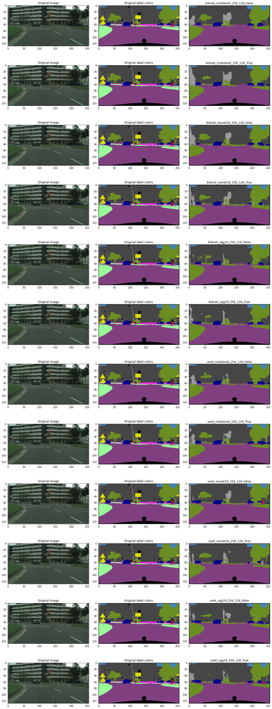

```python
# plot images
fig, ax = plt.subplots(
            nrows=12,
            ncols=3,
            figsize=(16, 42),
        )

for i, model in enumerate(list(Path('output').glob("**/model.h5"))):
    name_model = str(list(Path('output').glob("**/model.h5"))[i])[7:-9]
    width = int(str(list(Path('output').glob("**/model.h5"))[0])[7:-9].split('_')[2])
    height = int(str(list(Path('output').glob("**/model.h5"))[0])[7:-9].split('_')[3])

    model = tf.keras.models.load_model(model, custom_objects={'jaccard_loss':sm.losses.JaccardLoss(),
                                                             'iou_score':sm.metrics.IOUScore(threshold=0.5)})

    ax[i][0].title.set_text("Original image")
    img_origin = tf.keras.utils.load_img(
            'data/leftImg8bit/train/aachen/aachen_000000_000019_leftImg8bit.png', target_size=(height,width)
        )
    ax[i][0].imshow(img_origin)

    ax[i][1].title.set_text("Original label colors")
    img_colors = tf.keras.utils.load_img(
            'data/gtFine/train/aachen/aachen_000000_000019_gtFine_color.png', target_size=(height,width)
        )
    ax[i][1].imshow(img_colors)


    ax[i][2].title.set_text(name_model)
    img = np.squeeze(
                np.argmax(
                    model.predict(np.expand_dims(img_origin, 0)), axis=-1
                )
            )

    pred_colors = np.empty(img.shape + (3,), dtype='uint8')
    for row in range(img.shape[0]):
        for col in range(img.shape[1]):
            pred_colors[row, col] = catid2color[img[row, col]]

    ax[i][2].imshow(pred_colors)

fig.tight_layout()
plt.show()
```

Affichons à présent le récapitulatif des résultats :

```python
# Take all results saved and concat them
frames = []
for csv in list(Path('output').glob("*/results.csv")):
    df = pd.read_csv(csv).tail(1)
    df.image_size = df.image_size.astype('object')
    df.at[df.index[0],'image_size'] = (256,128)
    frames.append(df.tail(1))
df_results = pd.concat(frames, ignore_index=True)#.drop_duplicates()
```

```python
df_results
```

|  | model | augmentation | image_size | train_time_epoch | loss_score | iou_score |
| --- | --- | --- | --- | --- | --- | --- |
| 0 | linknet_mobilenet | False | (256, 128) | 108.845502 | 0.392247 | 0.613860 |
| 1 | linknet_mobilenet | True | (256, 128) | 159.051690 | 0.385401 | 0.622244 |
| 2 | linknet_resnet18 | False | (256, 128) | 150.528230 | 0.411113 | 0.595377 |
| 3 | linknet_resnet18 | True | (256, 128) | 157.740707 | 0.401401 | 0.604831 |
| 4 | linknet_vgg19 | False | (256, 128) | 151.578635 | 0.393142 | 0.613053 |
| 5 | linknet_vgg19 | True | (256, 128) | 162.396531 | 0.390136 | 0.614345 |
| 6 | unet_mobilenet | False | (256, 128) | 151.176559 | 0.368693 | 0.635327 |
| 7 | unet_mobilenet | True | (256, 128) | 157.281896 | 0.370636 | 0.636360 |
| 8 | unet_resnet18 | False | (256, 128) | 149.373338 | 0.383981 | 0.621465 |
| 9 | unet_resnet18 | True | (256, 128) | 159.503214 | 0.387844 | 0.617876 |
| 10 | unet_vgg19 | False | (256, 128) | 153.347840 | 0.382226 | 0.622685 |
| 11 | unet_vgg19 | True | (256, 128) | 164.089530 | 0.374129 | 0.631285 |

```python
import seaborn as sns
```

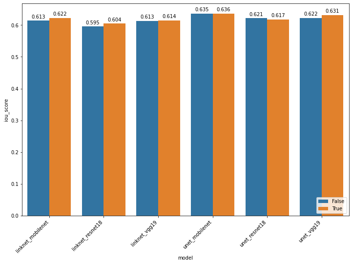

```python
plt.figure(figsize=(12,8))
ax = sns.barplot(x="model", y="iou_score", hue="augmentation", data=df_results)
for p in ax.patches:
        left, bottom, width, height = p.get_bbox().bounds
        ax.annotate(str(p.get_height())[:5], xy=(left + width / 2, height * 1.02),
                    ha='center', va='center')
plt.xticks(rotation=45, ha='right')
plt.legend(loc = "lower right")
plt.show()
```

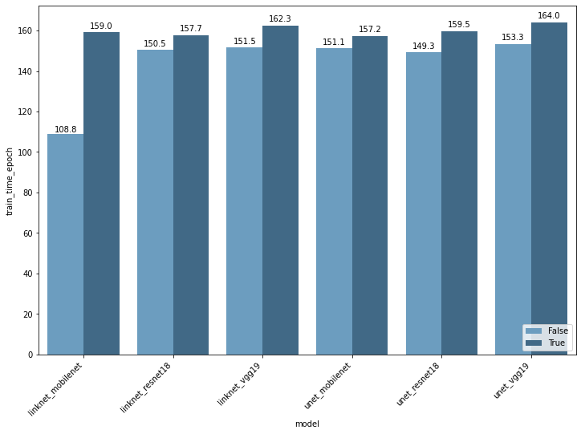

```python
plt.figure(figsize=(12,8))
ax = sns.barplot(x="model", y="train_time_epoch", hue="augmentation", data=df_results, palette="Blues_d")
for p in ax.patches:
        left, bottom, width, height = p.get_bbox().bounds
        ax.annotate(str(p.get_height())[:5], xy=(left + width / 2, height * 1.02),
                    ha='center', va='center')
plt.xticks(rotation=45, ha='right')
plt.legend(loc = "lower right")
plt.show()
```

Nous voyons que les modèles entrainés avec de la data augmentation ont de meilleures perfomances que ceux sans data augmentation, sauf pour le cas du modèle Unet + ResNet18.

La meilleure performance est atteinte par Unet + MobileNet avec une taille d'image de 256 pixels par 128 pixels avec data augmentation. Le modèle obtient 0.636 de IoU avec un temps d'entraiement par epoch de 157s qui est proche de la moyenne 152s.

Nous allons donc utiliser ce modèle comme modèle final.

## III) Entrainement sur Azure

```python
from azureml.core import Workspace, Run, Experiment, Datastore
from azureml.core.model import Model
from azureml.core.resource_configuration import ResourceConfiguration
```

### 3.1) Mise en place des données

```python
outputs_dir = os.path.join(os.getcwd(), 'outputs')
model_name = "model_final.h5"

ws = Workspace.from_config()# connect to your workspace
exp = Experiment(workspace=ws, name="p8-exp") # Load or create an experiment
```

```python
BATCH_SIZE = 16
EPOCHS = 25
```

```python
leftImg8bit_path = Path('data', "leftImg8bit")
gtFine_path = Path('data', "gtFine")

X_train_path = list(Path(leftImg8bit_path, "train").glob("**/*_leftImg8bit.png"))
y_train_path = list(Path(gtFine_path, "train").glob("**/*_labelIds.png"))

X_val_path = list(Path(leftImg8bit_path, "val").glob("**/*_leftImg8bit.png"))
y_val_path = list(Path(gtFine_path, "val").glob("**/*_labelIds.png"))
c_val_path = list(Path(gtFine_path, "val").glob("**/*_color.png"))
```

```python
train_gen = Generator(X_train_path, y_train_path,
                      cat2id=category2catid, labelid2catid=labelid2catid,
                      dim=(256,128), apply_augmentation=True,
                      batch_size=BATCH_SIZE, shuffle=False)

val_gen = Generator(X_val_path, y_val_path,
                    cat2id=category2catid, labelid2catid=labelid2catid,
                    dim=(256,128),batch_size=1, shuffle=False)
```

### 3.2) Mise en place du modèle

```python
model = sm.Unet("mobilenet", classes=8, activation='softmax')
model.compile(loss=sm.losses.JaccardLoss(), optimizer='adam', metrics=[sm.metrics.IOUScore(threshold=0.5)])
```

```python
if not os.path.isdir(outputs_dir): # create 'outputs' folder if it is not exists
    os.makedirs(outputs_dir)
model_path = os.path.join(outputs_dir, model_name)
checkpoint_cb = ModelCheckpoint(model_path, monitor='val_loss', save_best_only=True)
```

```python
# callback Azure to save logs
class AzureMlKerasCallback(Callback):

    def __init__(self, run):
        super(AzureMlKerasCallback, self).__init__()
        self.run = run

    def on_epoch_end(self, epoch, logs=None):
        logs = logs or {}
        send = {}
        send['epoch'] = epoch
        for k, v in logs.items():
            if isinstance(v, (np.ndarray, np.generic)):
                send[k] = v.item()
            else:
                send[k] = v
        for k, v in send.items():
            if isinstance(v, list):
                self.run.log_list(k, v)
            else:
                self.run.log(k, v)
```

### 3.3) Enregistrement des données dans Dataset Azure

Nous allons à présent enregistrer nos données dans un Dataset Azure afin d'y avoir accèss :

```python
from azureml.core import Dataset

blob_ds = ws.get_default_datastore()

blob_ds.upload(src_dir='data', target_path='cityscapes', overwrite=False)

file_ds = Dataset.File.from_files(path=(blob_ds, 'cityscapes'))
file_ds = file_ds.register(workspace=ws, name='cityscapes',create_new_version=True)
```

### 3.4) Entrainement

Entrainons notre modèle final puis enregistrons notre modèle sur le service Azure Model Registry :

```python
# Create a run
with exp.start_logging(snapshot_directory=None) as run:

    # Create an Azure Machine Learning monitor callback
    azureml_cb = AzureMlKerasCallback(run)

    # Training
    model.fit(train_gen, validation_data=val_gen, epochs=EPOCHS,
                     callbacks=[EarlyStopping(monitor='val_loss', mode='min', verbose=1, patience=5),
                                checkpoint_cb,
                                azureml_cb])


    # Load the best model
    model = tf.keras.models.load_model(model_path, custom_objects={'jaccard_loss':sm.losses.JaccardLoss(),
                                                   'iou_score':sm.metrics.IOUScore(threshold=0.5)})

    # Score trained model
    scores = model.evaluate(val_gen)
    print('Test jaccard_loss:', scores[0])
    run.log('Test jaccard_loss', scores[0])
    print('Test iou_score:', scores[1])
    run.log('Test iou_score', scores[1])

    # Upload the best model
    run.upload_file(model_name, model_path)

    # Register the best model
    run.register_model(model_name, model_path=model_name, model_framework="Custom")
```

### 3.5) Deploiement

Déployons enfin notre modèle enregistré sur Azure pouur y avoir accès via une API que nous pouront utiliser dans une web app :

```python
from azureml.core.environment import Environment
from azureml.core.conda_dependencies import CondaDependencies
from azureml.core.model import InferenceConfig
from azureml.core.webservice import AciWebservice, Webservice

model_name = "model_final.h5"
service_name = 'self-driving-service'
model = Model(ws, model_name)

env = Environment.from_conda_specification(name=service_name, file_path="dependencies.yml")
inference_config = InferenceConfig(entry_script="score.py", environment=env)
deployment_config = AciWebservice.deploy_configuration(cpu_cores=1, memory_gb=2)

service = Model.deploy(ws, service_name, [model], inference_config, deployment_config, overwrite=True)
service.wait_for_deployment(show_output=True)

print(service.state)
print("Scoring URL: " + service.scoring_uri)
```

```
Tips: You can try get_logs(): https://aka.ms/debugimage#dockerlog or local deployment: https://aka.ms/debugimage#debug-locally to debug if deployment takes longer than 10 minutes.
Running
2022-05-13 21:53:51+01:00 Creating Container Registry if not exists.
2022-05-13 21:53:51+01:00 Registering the environment.
2022-05-13 21:53:52+01:00 Use the existing image.
2022-05-13 21:53:52+01:00 Generating deployment configuration.
2022-05-13 21:53:53+01:00 Submitting deployment to compute.
2022-05-13 21:53:56+01:00 Checking the status of deployment self-driving-service..
2022-05-13 21:56:04+01:00 Checking the status of inference endpoint self-driving-service.
Succeeded
ACI service creation operation finished, operation "Succeeded"
Healthy
Scoring URL: http://f005481c-af46-4421-b4c2-2f64453aa66c.eastus2.azurecontainer.io/score
```

## IV) Web App Flask sur Azure

Disponible à cette URL: https://self-driving-segmentation.azurewebsites.net/

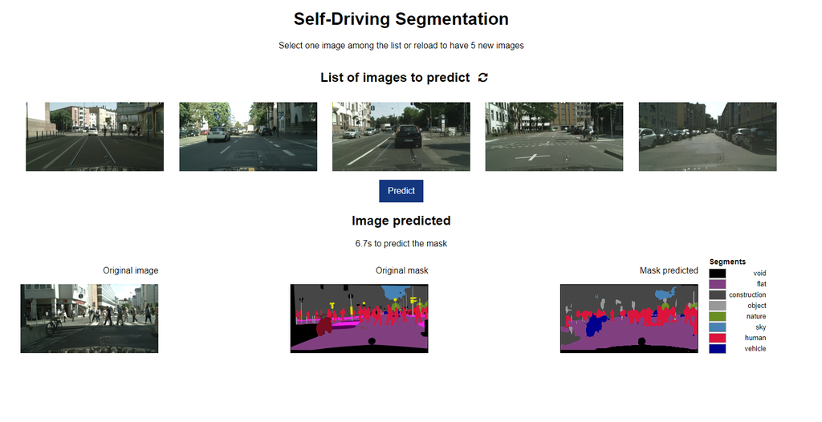